# Define Python Pandas?

```
Pandas refers to software library explicitly written for python, which is used to analyze and manipulate data. Pandas is a open source library created by Wes Mckinney. It was released in 2008 and provided Data structure and operations to manipulate numerical and time-series data.

Pandas makes it very easy to perform machine learning operations on tabular data.

Pandas is a package for data manipulation and analysis in Python. The name Pandas is derived from the econometrics term Panel Data.
```

```python
import pandas as pd

import numpy as np
```

```python
pd.__version__
```

```
'1.1.1'
```

## Why do you use Pandas?

**Data representation** Pandas provides extremely streamlined form of data representation. This helps to analyze and understand data bettery

**Less Writing and more done**: using pandas helps us to shorten the procedue of handling data, with time saved we can focus more on data analysis.

**Pandas are really powerfull**, they provide us with huge set of important commands and features which are used to easily analyze the data.

**Efficiently handles large data** Pandas help to save a lot of time by importing large amounts of data very fast.

## Key features of Pandas:

```
Fast and efficient DataFrame object with default and customized indexing.**

Tools for loading data into memory data objects from different file formats**

Data alignment and handling of missing data**

Label based slicing, indexing and subsetting of large data sets.**

Columns from the data structure can be deleted or inserted.**

High performace merging and joining of data.**
```

# What are the different types of Data structures in Pandas?

Pandas library support two major types of Data structures, **DataFrame** and **Series.**

Both these data structures are build on the top of Numpy.

Series is a **one dimensional** and simple Data structure.

Another axis label is known as **Panel** is a **3 - dimensional data structure.**

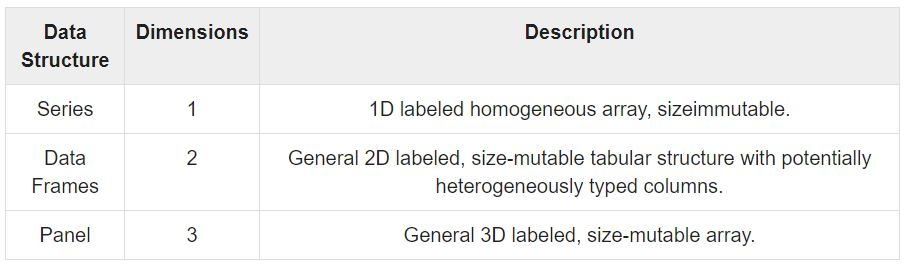

# Explain Series in Pandas

```
Series is one dimensional array that can hold data values of any one data type(string, float, integer, python objects).

Here the data axis label are called index.
```

**Key Points**

```
Homogeneous data
Size Immutable
Values of Data Mutable
```

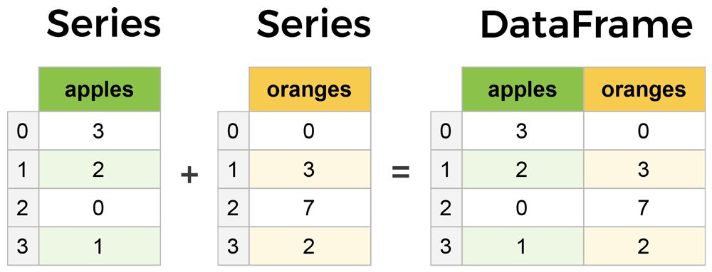

**Syntax for Series = pd.Series(Data, index, dtype, name, copy, fastpath)**

```python
# Create an empty Series

empty_ser = pd.Series(dtype = 'float')

print(empty_ser)
```

```
Series([], dtype: float64)
```

```python
# Series example

data = np.array(['g','e','e','k','s'])

print(data)

s = pd.Series(data)

print(s)
```

```
['g' 'e' 'e' 'k' 's']
0    g
1    e
2    e
3    k
4    s
dtype: object
```

```python
se = pd.Series(5, index=[0, 1, 2, 3])   # index can be any number or either alphabets.

print(se)
```

```
0    5
1    5
2    5
3    5
dtype: int64
```

```python
pd.Series([20,25,30,40], index = [1,2,3,4], name = 'new_series')
```

```
1    20
2    25
3    30
4    40
Name: new_series, dtype: int64
```